# GO, KEGG, and GSEA Enrichment Analysis Workflow

Kiran Adhikari

2026-04-12

# 1 Overview

**What is this?** This is a complete, step-by-step guide to analyze your RNA-seq data using three different enrichment methods: GO, KEGG, and GSEA. Each method helps you understand which biological pathways or functions are important in your experiment.

## 1.1 Assumptions

- You already ran DESeq2 (or similar)
- You have a results table with gene-level statistics

## 1.2 Input Requirements

Your DE results must contain:

| Column | Description |
| --- | --- |
| `gene` | Gene symbol (recommended) |
| `log2FoldChange` | Effect size |
| `padj` | Adjusted p-value |
| `stat` | Wald / t statistic (for GSEA) |

Example: `res_df`

# 2 Package Installation and Loading

**What is this?** We need to install and load R packages (tools) that help us do the enrichment analysis. These packages contain functions to connect genes to biological pathways.

Load Library

```r
# Load required libraries
library(clusterProfiler)
library(org.Hs.eg.db)
library(enrichplot)
library(dplyr)
library(ggplot2)
library(gridExtra)
library(patchwork)
```

# 3 Data Loading

**What is this?** We read your differential expression results file. This file contains information about which genes changed between your experimental groups (like control vs treatment).

### 3.0.1 Read the DE results

```r
# Load DE results from file
# Update the path to your specific comparison
data_path <- "RNAseq-test-VS-Control-all-ge-difference.txt"

# Read the DE results
res_df <- read.delim(data_path, sep = "\t", stringsAsFactors = FALSE)

# Check data structure
head(res_df)
```

```
##      gene  baseMean log2FoldChange     lfcSE     stat       pvalue         padj
## 1    MMP9  692.1816       3.153371 0.1552285 20.31438 9.595635e-92 1.337152e-87
## 2  COL1A1  728.2604       2.276374 0.1201788 18.94156 5.183828e-80 3.611832e-76
## 3   TGFBI 7218.2938       1.692710 0.0946255 17.88852 1.449139e-71 6.731253e-68
## 4  COL1A2  216.6654       2.946119 0.1827432 16.12164 1.797777e-58 6.263004e-55
## 5 COL22A1  465.0686       1.710837 0.1089382 15.70466 1.405308e-55 3.916593e-52
## 6   POSTN 1042.1997       2.150821 0.1580978 13.60437 3.772121e-42 8.760751e-39
```

```r
str(res_df)
```

```
## 'data.frame':    19134 obs. of  7 variables:
##  $ gene          : chr  "MMP9" "COL1A1" "TGFBI" "COL1A2" ...
##  $ baseMean      : num  692 728 7218 217 465 ...
##  $ log2FoldChange: num  3.15 2.28 1.69 2.95 1.71 ...
##  $ lfcSE         : num  0.1552 0.1202 0.0946 0.1827 0.1089 ...
##  $ stat          : num  20.3 18.9 17.9 16.1 15.7 ...
##  $ pvalue        : num  9.60e-92 5.18e-80 1.45e-71 1.80e-58 1.41e-55 ...
##  $ padj          : num  1.34e-87 3.61e-76 6.73e-68 6.26e-55 3.92e-52 ...
```

# 4 Data Preparation

**What is this?** We clean up the data by removing genes that have missing or invalid statistics. This ensures our analysis only uses reliable data.

```r
# Remove NA statistics
res_df <- res_df %>%
  filter(!is.na(stat), !is.na(gene))

# Check number of genes
cat("Total genes:", nrow(res_df), "\n")
```

```
## Total genes: 19134
```

```r
cat("Genes with valid statistics:", nrow(res_df), "\n")
```

```
## Genes with valid statistics: 19134
```

# 5 Analysis 1: GO Enrichment

**What is this?** GO (Gene Ontology) enrichment finds which biological processes, molecular functions, or cellular components are over-represented in your list of significantly changed genes. It only looks at genes that passed your significance thresholds.

**DEG-based Over-Representation Analysis**

## 5.1 Select DEGs

```r
# Select DEGs
deg_genes <- res_df %>%
  filter(padj < 0.05, abs(log2FoldChange) > 1) %>%
  pull(gene)
```

## 5.2 Run GO Enrichment

```r
ego <- enrichGO(
  gene          = deg_genes,
  OrgDb         = org.Hs.eg.db,
  keyType       = "SYMBOL",
  ont           = "BP",        # BP / MF / CC
  pAdjustMethod = "BH",
  pvalueCutoff  = 0.05,
  qvalueCutoff  = 0.05
)

# View results
head(ego@result)
```

```
##                    ID                                   Description GeneRatio
## GO:0030198 GO:0030198             extracellular matrix organization    23/112
## GO:0043062 GO:0043062          extracellular structure organization    23/112
## GO:0045229 GO:0045229 external encapsulating structure organization    23/112
## GO:0022617 GO:0022617              extracellular matrix disassembly     8/112
## GO:0032963 GO:0032963                    collagen metabolic process     9/112
## GO:0030199 GO:0030199                  collagen fibril organization     7/112
##              BgRatio       pvalue     p.adjust       qvalue
## GO:0030198 321/18870 1.087925e-18 9.582554e-16 7.617801e-16
## GO:0043062 322/18870 1.166242e-18 9.582554e-16 7.617801e-16
## GO:0045229 323/18870 1.249898e-18 9.582554e-16 7.617801e-16
## GO:0022617  62/18870 3.097513e-09 1.781070e-06 1.415889e-06
## GO:0032963 106/18870 1.341024e-08 6.168711e-06 4.903913e-06
## GO:0030199  65/18870 1.125661e-07 4.315036e-05 3.430305e-05
##                                                                                                                                                          geneID
## GO:0030198 MMP9/COL1A1/TGFBI/COL1A2/COL22A1/POSTN/MMP2/MELTF/MMP10/OLFML2A/HAS2/COL11A1/DPP4/CTSS/ADAMTS7/CREB3L1/GREM1/IL6/ABI3BP/COL3A1/CYP1B1/ADAMTS15/ITGB3
## GO:0043062 MMP9/COL1A1/TGFBI/COL1A2/COL22A1/POSTN/MMP2/MELTF/MMP10/OLFML2A/HAS2/COL11A1/DPP4/CTSS/ADAMTS7/CREB3L1/GREM1/IL6/ABI3BP/COL3A1/CYP1B1/ADAMTS15/ITGB3
## GO:0045229 MMP9/COL1A1/TGFBI/COL1A2/COL22A1/POSTN/MMP2/MELTF/MMP10/OLFML2A/HAS2/COL11A1/DPP4/CTSS/ADAMTS7/CREB3L1/GREM1/IL6/ABI3BP/COL3A1/CYP1B1/ADAMTS15/ITGB3
## GO:0022617                                                                                                         MMP9/MMP2/MELTF/MMP10/DPP4/CTSS/IL6/ADAMTS15
## GO:0032963                                                                                                  MMP9/COL1A1/COL1A2/MMP2/MMP10/CTSS/KLK6/CREB3L1/IL6
## GO:0030199                                                                                                    COL1A1/COL1A2/COL11A1/ADAMTS7/GREM1/COL3A1/CYP1B1
##            Count
## GO:0030198    23
## GO:0043062    23
## GO:0045229    23
## GO:0022617     8
## GO:0032963     9
## GO:0030199     7
```

## 5.3 GO Enrichment Results Table

**What is this?** This table shows all the GO terms that are over-represented in your significantly changed genes. Each row is a biological process, function, or component that your genes are involved in.

```r
# Format GO enrichment results table
if(nrow(ego@result) > 0) {
  go_table <- ego@result %>%
    select(ID, Description, Count, GeneRatio, BgRatio, pvalue, p.adjust, qvalue) %>%
    mutate(
      `p-value` = formatC(pvalue, format = "e", digits = 2),
      `p-adjust` = formatC(p.adjust, format = "e", digits = 2),
      `q-value` = formatC(qvalue, format = "e", digits = 2)
    ) %>%
    rename(
      `Gene Count` = Count,
      `Gene Ratio` = GeneRatio,
      `Background Ratio` = BgRatio
    ) %>%
    select(ID, Description, `Gene Count`, `Gene Ratio`, `Background Ratio`, `p-value`, `p-adjust`, `q-value`)

  knitr::kable(head(go_table),
                caption = "GO Enrichment Results",
                digits = 6)
}
```

GO Enrichment Results

|  | ID | Description | Gene Count | Gene Ratio | Background Ratio | p-value | p-adjust | q-value |
| --- | --- | --- | --- | --- | --- | --- | --- | --- |
| GO:0030198 | GO:0030198 | extracellular matrix organization | 23 | 23/112 | 321/18870 | 1.09e-18 | 9.58e-16 | 7.62e-16 |
| GO:0043062 | GO:0043062 | extracellular structure organization | 23 | 23/112 | 322/18870 | 1.17e-18 | 9.58e-16 | 7.62e-16 |
| GO:0045229 | GO:0045229 | external encapsulating structure organization | 23 | 23/112 | 323/18870 | 1.25e-18 | 9.58e-16 | 7.62e-16 |
| GO:0022617 | GO:0022617 | extracellular matrix disassembly | 8 | 8/112 | 62/18870 | 3.10e-09 | 1.78e-06 | 1.42e-06 |
| GO:0032963 | GO:0032963 | collagen metabolic process | 9 | 9/112 | 106/18870 | 1.34e-08 | 6.17e-06 | 4.90e-06 |
| GO:0030199 | GO:0030199 | collagen fibril organization | 7 | 7/112 | 65/18870 | 1.13e-07 | 4.32e-05 | 3.43e-05 |

## 5.4 Plot GO Results

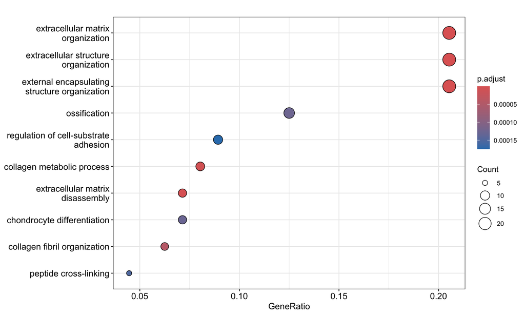

```r
dotplot(ego, showCategory = 10)
```

# 6 Analysis 2: KEGG Enrichment

**What is this?** KEGG enrichment finds which biological pathways (like “Cell cycle” or “Immune response”) are over-represented in your significantly changed genes. It uses the KEGG pathway database which contains well-studied biological pathways.

**DEG-based Pathway Analysis**

## 6.1 Convert SYMBOL to ENTREZ

```r
# Convert SYMBOL → ENTREZ
deg_entrez <- bitr(
  deg_genes,
  fromType = "SYMBOL",
  toType   = "ENTREZID",
  OrgDb    = org.Hs.eg.db
)
```

## 6.2 Run KEGG Enrichment

```r
ekk <- enrichKEGG(
  gene          = deg_entrez$ENTREZID,
  organism      = "hsa",
  pvalueCutoff  = 0.05
)

# View results
head(ekk@result)
```

```
##                                      category                     subcategory
## hsa04933                       Human Diseases Endocrine and metabolic disease
## hsa04974                   Organismal Systems                Digestive system
## hsa04382                                 <NA>                            <NA>
## hsa05150                       Human Diseases   Infectious disease: bacterial
## hsa05146                       Human Diseases   Infectious disease: parasitic
## hsa04668 Environmental Information Processing             Signal transduction
##                ID                                          Description
## hsa04933 hsa04933 AGE-RAGE signaling pathway in diabetic complications
## hsa04974 hsa04974                     Protein digestion and absorption
## hsa04382 hsa04382                         Cornified envelope formation
## hsa05150 hsa05150                      Staphylococcus aureus infection
## hsa05146 hsa05146                                           Amoebiasis
## hsa04668 hsa04668                                TNF signaling pathway
##          GeneRatio  BgRatio       pvalue    p.adjust      qvalue
## hsa04933      7/73 101/9376 1.243065e-05 0.001371964 0.001161294
## hsa04974      7/73 103/9376 1.414396e-05 0.001371964 0.001161294
## hsa04382      9/73 217/9376 4.334099e-05 0.002802717 0.002372349
## hsa05150      6/73  99/9376 1.144320e-04 0.005528519 0.004679593
## hsa05146      6/73 103/9376 1.424876e-04 0.005528519 0.004679593
## hsa04668      6/73 119/9376 3.135580e-04 0.010138376 0.008581588
##                                                       geneID Count
## hsa04933                  1277/1278/4313/3383/2335/3569/1281     7
## hsa04974                1277/1278/169044/1301/1803/5646/1281     7
## hsa04382 192666/1823/6707/3851/3848/126410/25984/3849/121214     9
## hsa05150                      3383/716/192666/715/25984/1675     6
## hsa05146                        1277/1278/2335/384/3569/1281     6
## hsa04668                       4318/3383/330/90993/3569/3627     6
```

## 6.3 KEGG Enrichment Results Table

**What is this?** This table shows all the KEGG pathways that are over-represented in your significantly changed genes. Each row is a biological pathway that your genes belong to.

```r
# Format KEGG enrichment results table
if(nrow(ekk@result) > 0) {
  kegg_table <- ekk@result %>%
    select(ID, Description, Count, GeneRatio, BgRatio, pvalue, p.adjust, qvalue) %>%
    mutate(
      `p-value` = formatC(pvalue, format = "e", digits = 2),
      `p-adjust` = formatC(p.adjust, format = "e", digits = 2),
      `q-value` = formatC(qvalue, format = "e", digits = 2)
    ) %>%
    rename(
      `Gene Count` = Count,
      `Gene Ratio` = GeneRatio,
      `Background Ratio` = BgRatio
    ) %>%
    select(ID, Description, `Gene Count`, `Gene Ratio`, `Background Ratio`, `p-value`, `p-adjust`, `q-value`)

  knitr::kable(head(kegg_table),
                caption = "KEGG Enrichment Results",
                digits = 6)
}
```

KEGG Enrichment Results

|  | ID | Description | Gene Count | Gene Ratio | Background Ratio | p-value | p-adjust | q-value |
| --- | --- | --- | --- | --- | --- | --- | --- | --- |
| hsa04933 | hsa04933 | AGE-RAGE signaling pathway in diabetic complications | 7 | 7/73 | 101/9376 | 1.24e-05 | 1.37e-03 | 1.16e-03 |
| hsa04974 | hsa04974 | Protein digestion and absorption | 7 | 7/73 | 103/9376 | 1.41e-05 | 1.37e-03 | 1.16e-03 |
| hsa04382 | hsa04382 | Cornified envelope formation | 9 | 9/73 | 217/9376 | 4.33e-05 | 2.80e-03 | 2.37e-03 |
| hsa05150 | hsa05150 | Staphylococcus aureus infection | 6 | 6/73 | 99/9376 | 1.14e-04 | 5.53e-03 | 4.68e-03 |
| hsa05146 | hsa05146 | Amoebiasis | 6 | 6/73 | 103/9376 | 1.42e-04 | 5.53e-03 | 4.68e-03 |
| hsa04668 | hsa04668 | TNF signaling pathway | 6 | 6/73 | 119/9376 | 3.14e-04 | 1.01e-02 | 8.58e-03 |

## 6.4 Plot KEGG Results

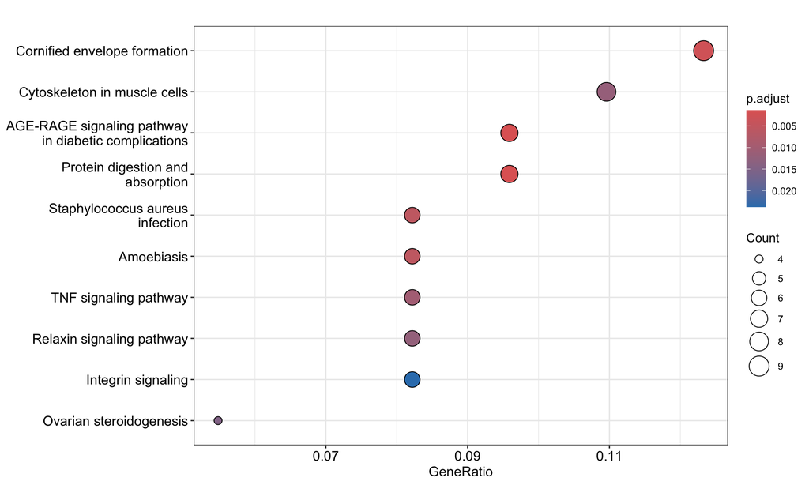

```r
dotplot(ekk, showCategory = 10)
```

# 7 Analysis 3: GSEA

**What is this?** GSEA (Gene Set Enrichment Analysis) is different from GO and KEGG. Instead of only looking at significantly changed genes, it uses ALL your genes ranked by how much they changed. This helps find pathways that might be important but don’t show up in the other methods.

**Rank-based, NO DEG filtering**

## 7.1 Create Ranked Gene List

```r
# Create ranked gene list (ALL genes)
gene_rank <- res_df$stat
names(gene_rank) <- res_df$gene

gene_rank <- sort(gene_rank, decreasing = TRUE)
```

> **⚠️ Important:** Do NOT filter by padj or logFC for GSEA

## 7.2 GSEA with GO (rank-based)

```r
gsea_go <- gseGO(
  geneList     = gene_rank,
  OrgDb        = org.Hs.eg.db,
  keyType      = "SYMBOL",
  ont          = "BP",
  minGSSize    = 10,
  maxGSSize    = 500,
  pvalueCutoff = 0.25,   # GSEA standard
  verbose      = FALSE
)

# View results
head(gsea_go@result)
```

```
##                    ID                          Description setSize
## GO:0002181 GO:0002181              cytoplasmic translation     154
## GO:0032543 GO:0032543            mitochondrial translation     130
## GO:0009060 GO:0009060                  aerobic respiration     173
## GO:0030198 GO:0030198    extracellular matrix organization     256
## GO:0043062 GO:0043062 extracellular structure organization     256
## GO:0006119 GO:0006119            oxidative phosphorylation     127
##            enrichmentScore       NES pvalue    p.adjust   qvalue rank
## GO:0002181      -0.7410805 -3.201848  1e-10 7.04625e-09 4.65e-09 2280
## GO:0032543      -0.6984170 -2.951462  1e-10 7.04625e-09 4.65e-09 2737
## GO:0009060      -0.6647406 -2.923171  1e-10 7.04625e-09 4.65e-09 4202
## GO:0030198       0.6391137  2.918806  1e-10 7.04625e-09 4.65e-09 2025
## GO:0043062       0.6391137  2.918806  1e-10 7.04625e-09 4.65e-09 2025
## GO:0006119      -0.6892360 -2.911996  1e-10 7.04625e-09 4.65e-09 4269
##                              leading_edge
## GO:0002181 tags=66%, list=12%, signal=58%
## GO:0032543 tags=64%, list=14%, signal=55%
## GO:0009060 tags=75%, list=22%, signal=59%
## GO:0030198 tags=36%, list=11%, signal=33%
## GO:0043062 tags=36%, list=11%, signal=33%
## GO:0006119 tags=78%, list=22%, signal=61%
##                                                                                                                                                                                                                                                                                                          …
## GO:0002181                                                                                                                                                                                                                                                              RWDD1/CNBP/RPLP0P6/EIF3M/RPS27A/E…
## GO:0032543                                                                                                                                                                                                                                                                                               …
## GO:0009060 TAFAZZIN/NDUFS7/NDUFA3/MTFR1L/MDH1B/NDUFA2/AK4/DHTKD1/TMEM135/ATP5PD/NDUFB1/UQCC3/MSH2/PPIF/CYCS/NDUFA11/NDUFC2-KCTD14/SUCLG2/SIRT3/COX7B/ATP5F1E/NDUFB5/ATP5PF/PDHA1/COQ9/I…
## GO:0030198                                                                                                                                                                                                                                                                             MMP9/COL1A1/TGFBI/…
## GO:0043062                                                                                                                                                                                                                                                                             MMP9/COL1A1/TGFBI/…
## GO:0006119                                                                                                                                                                                   TAFAZZIN/NDUFS7/NDUFA3/NDUFA2/AK4/TMEM135/ATP5PD/NDUFB1/UQCC3/MSH2/PPIF/CYCS/NDUFA11/NDUFC2-KCTD14/COX7B/ATP…
```

## 7.3 GSEA-GO Results Table

**What is this?** This table shows all the GO terms that were enriched in your data. The columns tell you how significant each result is and how strong the enrichment is.

```r
# Format GSEA-GO results table
if(nrow(gsea_go@result) > 0) {
  # Check available columns and use the correct column names
  available_cols <- colnames(gsea_go@result)

  # Create table with available columns
  gsea_go_table <- gsea_go@result %>%
    select(ID, Description, setSize)

  # Add ES column (might be enrichmentScore in some versions)
  if("enrichmentScore" %in% available_cols) {
    gsea_go_table$ES <- gsea_go@result$enrichmentScore
  } else if("ES" %in% available_cols) {
    gsea_go_table$ES <- gsea_go@result$ES
  }

  # Add other columns if they exist
  if("NES" %in% available_cols) {
    gsea_go_table$NES <- gsea_go@result$NES
  }
  if("pvalue" %in% available_cols) {
    gsea_go_table$`p-value` <- gsea_go@result$pvalue
  }
  if("p.adjust" %in% available_cols) {
    gsea_go_table$`p-adjust` <- gsea_go@result$p.adjust
  }
  if("qvalue" %in% available_cols) {
    gsea_go_table$`q-value` <- gsea_go@result$qvalue
  }

  # Format the table
  gsea_go_table <- gsea_go_table %>%
    mutate(
      `Set size` = setSize
    )

  # Round numeric columns
  if("ES" %in% colnames(gsea_go_table)) {
    gsea_go_table$ES <- round(gsea_go_table$ES, 6)
  }
  if("NES" %in% colnames(gsea_go_table)) {
    gsea_go_table$NES <- round(gsea_go_table$NES, 6)
  }
  if("p-value" %in% colnames(gsea_go_table)) {
    gsea_go_table$`p-value` <- formatC(gsea_go_table$`p-value`, format = "e", digits = 2)
  }
  if("p-adjust" %in% colnames(gsea_go_table)) {
    gsea_go_table$`p-adjust` <- formatC(gsea_go_table$`p-adjust`, format = "e", digits = 2)
  }
  if("q-value" %in% colnames(gsea_go_table)) {
    gsea_go_table$`q-value` <- formatC(gsea_go_table$`q-value`, format = "e", digits = 2)
  }

  # Select final columns
  final_cols <- c("ID", "Description", "Set size")
  if("ES" %in% colnames(gsea_go_table)) final_cols <- c(final_cols, "ES")
  if("NES" %in% colnames(gsea_go_table)) final_cols <- c(final_cols, "NES")
  if("p-value" %in% colnames(gsea_go_table)) final_cols <- c(final_cols, "p-value")
  if("p-adjust" %in% colnames(gsea_go_table)) final_cols <- c(final_cols, "p-adjust")
  if("q-value" %in% colnames(gsea_go_table)) final_cols <- c(final_cols, "q-value")

  gsea_go_table <- gsea_go_table %>% select(all_of(final_cols))

  knitr::kable(head(gsea_go_table),
                caption = "GSEA-GO Enrichment Results",
                digits = 6)
}
```

GSEA-GO Enrichment Results

|  | ID | Description | Set size | ES | NES | p-value | p-adjust | q-value |
| --- | --- | --- | --- | --- | --- | --- | --- | --- |
| GO:0002181 | GO:0002181 | cytoplasmic translation | 154 | -0.741080 | -3.201848 | 1.00e-10 | 7.05e-09 | 4.65e-09 |
| GO:0032543 | GO:0032543 | mitochondrial translation | 130 | -0.698417 | -2.951462 | 1.00e-10 | 7.05e-09 | 4.65e-09 |
| GO:0009060 | GO:0009060 | aerobic respiration | 173 | -0.664741 | -2.923171 | 1.00e-10 | 7.05e-09 | 4.65e-09 |
| GO:0030198 | GO:0030198 | extracellular matrix organization | 256 | 0.639114 | 2.918806 | 1.00e-10 | 7.05e-09 | 4.65e-09 |
| GO:0043062 | GO:0043062 | extracellular structure organization | 256 | 0.639114 | 2.918806 | 1.00e-10 | 7.05e-09 | 4.65e-09 |
| GO:0006119 | GO:0006119 | oxidative phosphorylation | 127 | -0.689236 | -2.911996 | 1.00e-10 | 7.05e-09 | 4.65e-09 |

Plot gsea_go results

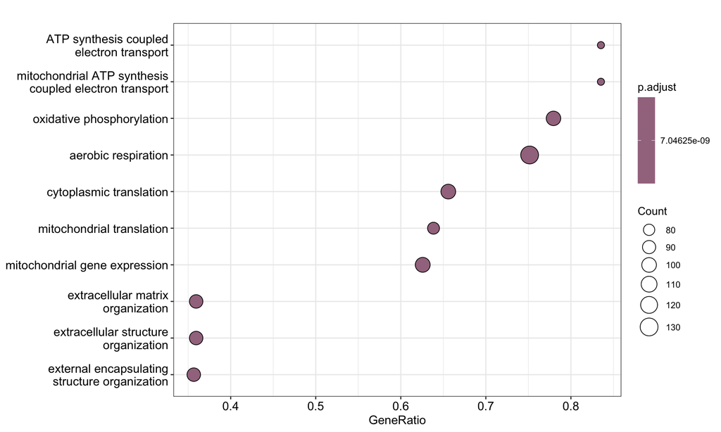

```r
dotplot(gsea_go, showCategory = 10)
```

## 7.4 GSEA with KEGG (rank-based)

```r
# Convert ALL genes to ENTREZ
rank_entrez <- bitr(
  names(gene_rank),
  fromType = "SYMBOL",
  toType   = "ENTREZID",
  OrgDb    = org.Hs.eg.db
)

gene_rank_kegg <- gene_rank[rank_entrez$SYMBOL]
names(gene_rank_kegg) <- rank_entrez$ENTREZID
gene_rank_kegg <- sort(gene_rank_kegg, decreasing = TRUE)
```

```r
gsea_kegg <- gseKEGG(
  geneList     = gene_rank_kegg,
  organism     = "hsa",
  pvalueCutoff = 0.25,
  verbose      = FALSE
)

# View results
head(gsea_kegg@result)
```

```
##                ID                 Description setSize enrichmentScore       NES
## hsa03010 hsa03010                    Ribosome     172      -0.7970577 -3.522653
## hsa04512 hsa04512    ECM-receptor interaction      66       0.7350669  2.746054
## hsa03050 hsa03050                  Proteasome      43      -0.7687131 -2.695400
## hsa01200 hsa01200           Carbon metabolism      98      -0.6328807 -2.588492
## hsa00190 hsa00190   Oxidative phosphorylation     112      -0.6214599 -2.581363
## hsa01230 hsa01230 Biosynthesis of amino acids      62      -0.6699157 -2.556907
##          pvalue     p.adjust       qvalue rank                   leading_edge
## hsa03010  1e-10 1.842105e-09 1.036011e-09 2632 tags=86%, list=16%, signal=73%
## hsa04512  1e-10 1.842105e-09 1.036011e-09 1046  tags=33%, list=6%, signal=31%
## hsa03050  1e-10 1.842105e-09 1.036011e-09 2425 tags=67%, list=14%, signal=58%
## hsa01200  1e-10 1.842105e-09 1.036011e-09 2972 tags=52%, list=18%, signal=43%
## hsa00190  1e-10 1.842105e-09 1.036011e-09 3421 tags=68%, list=20%, signal=54%
## hsa01230  1e-10 1.842105e-09 1.036011e-09 2375 tags=47%, list=14%, signal=40%
##                                                                                                                                                                                                                                                                                                          …
## hsa03010 92259/28977/6224/84311/54460/54534/6183/64981/63931/51649/21…
## hsa04512                                                                                                                                                                                                                                                                                                 …
## hsa03050                                                                                                                                                                                                                                                                                                 …
## hsa01200                                                                                                                                                                                                                                                                                                 …
## hsa00190                                                                                                                                                                                                                                                                                                 …
## hsa01230                                                                                                                                                                                                                                                                                                 …
```

Plot gsea_kegg results

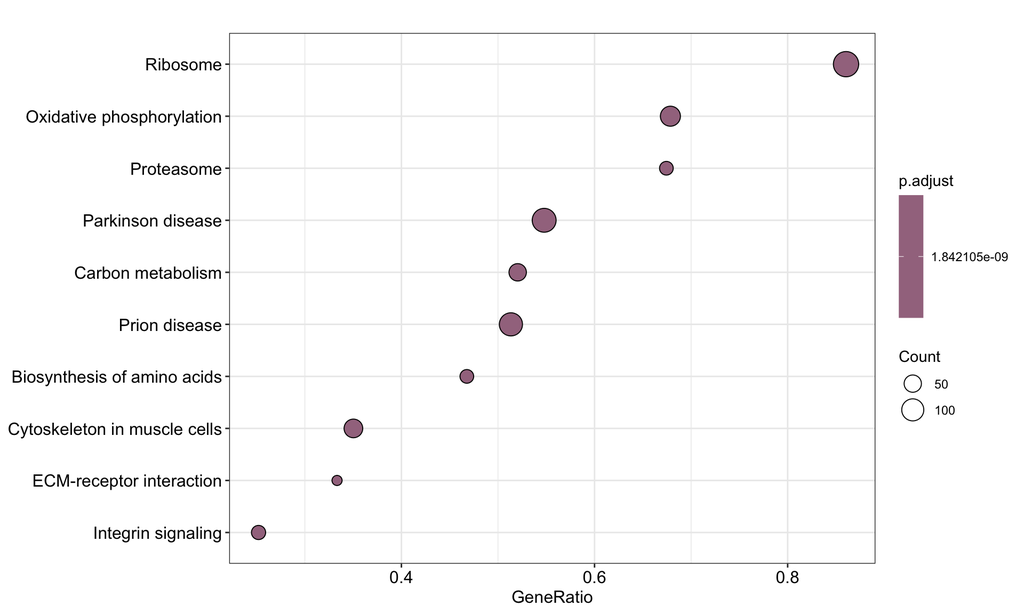

```r
dotplot(gsea_kegg, showCategory = 10)
```

## 7.5 Plot GSEA Results

For GO

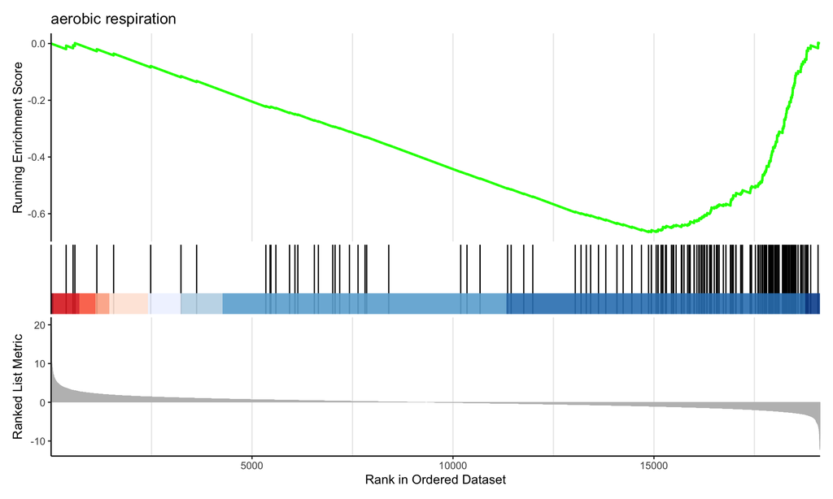

```r
# Single pathway plot
gseaplot2(
  gsea_go,
  geneSetID = gsea_go@result$ID[3],
  title     = gsea_go@result$Description[3]
)
```

For kegg

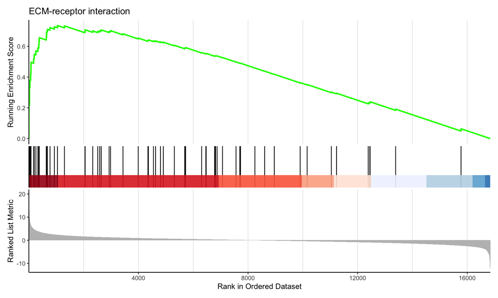

```r
# Single pathway plot
gseaplot2(
  gsea_kegg,
  geneSetID = gsea_kegg@result$ID[2],
  title     = gsea_kegg@result$Description[2]
)
```

```r
# Extract leading-edge genes (core drivers)
leading_edge_genes <- gsea_go@result %>%
  select(ID, Description, leading_edge)

head(leading_edge_genes)
```

```
##                    ID                          Description
## GO:0002181 GO:0002181              cytoplasmic translation
## GO:0032543 GO:0032543            mitochondrial translation
## GO:0009060 GO:0009060                  aerobic respiration
## GO:0030198 GO:0030198    extracellular matrix organization
## GO:0043062 GO:0043062 extracellular structure organization
## GO:0006119 GO:0006119            oxidative phosphorylation
##                              leading_edge
## GO:0002181 tags=66%, list=12%, signal=58%
## GO:0032543 tags=64%, list=14%, signal=55%
## GO:0009060 tags=75%, list=22%, signal=59%
## GO:0030198 tags=36%, list=11%, signal=33%
## GO:0043062 tags=36%, list=11%, signal=33%
## GO:0006119 tags=78%, list=22%, signal=61%
```

# 8 Side-by-Side Comparison: GO vs KEGG vs GSEA

## 8.2 Comparison Table

```r
# Create a summary table
comparison_table <- comparison_df %>%
  group_by(Method) %>%
  summarise(
    `Total Pathways` = n(),
    `Min P-adj` = min(Padj, na.rm = TRUE),
    `Max P-adj` = max(Padj, na.rm = TRUE),
    `Mean Gene Count` = round(mean(GeneCount, na.rm = TRUE), 1),
    `Mean Enrichment Score` = ifelse(Method %in% c("GSEA-GO", "GSEA-KEGG"),
                                     round(mean(EnrichmentScore, na.rm = TRUE), 2),
                                     NA)
  )

knitr::kable(head(comparison_table), caption = "Summary Statistics by Method")
```

[output not shown]

Summary Statistics by Method

[output not shown]

## 8.3 Comparison Visualizations

**What is this?** These plots help you visually compare the results from different methods. You can see which method finds more significant pathways and how the results differ.

### 8.3.1 1. P-value Distribution Comparison

**What is this?** This plot shows how significant the pathways are for each method. Higher values mean more significant results.

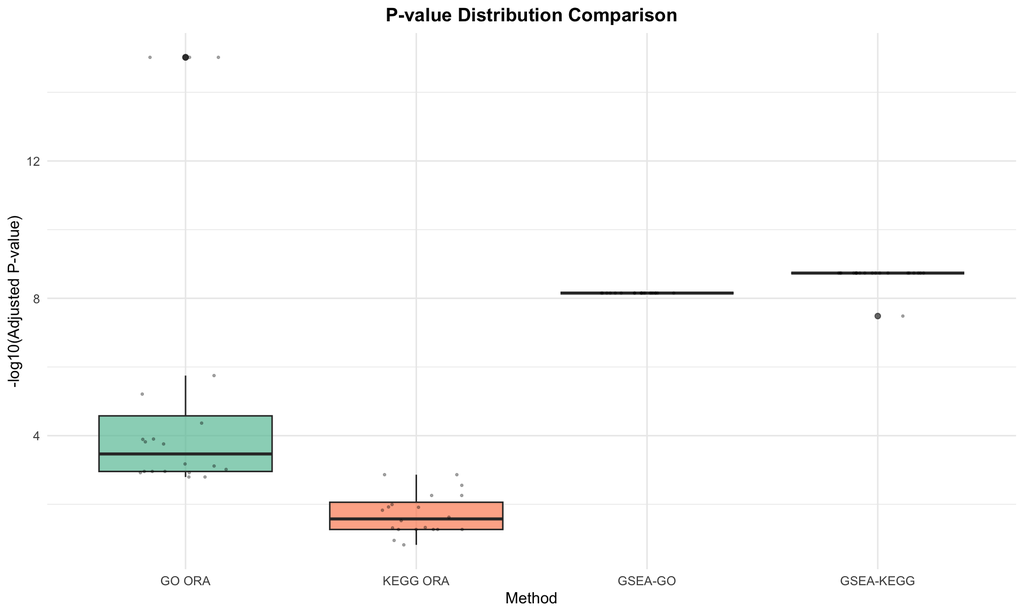

```r
p1 <- ggplot(comparison_df, aes(x = Method, y = log10Padj, fill = Method)) +
  geom_boxplot(alpha = 0.7) +
  geom_jitter(width = 0.2, alpha = 0.3, size = 0.5) +
  scale_fill_brewer(palette = "Set2") +
  labs(
    title = "P-value Distribution Comparison",
    x = "Method",
    y = "-log10(Adjusted P-value)"
  ) +
  theme_minimal() +
  theme(
    legend.position = "none",
    plot.title = element_text(hjust = 0.5, face = "bold")
  )

print(p1)
```

### 8.3.2 3. Gene Count Comparison

**What is this?** This plot shows how many genes are in each enriched pathway. Some pathways are large (many genes), others are small (few genes).

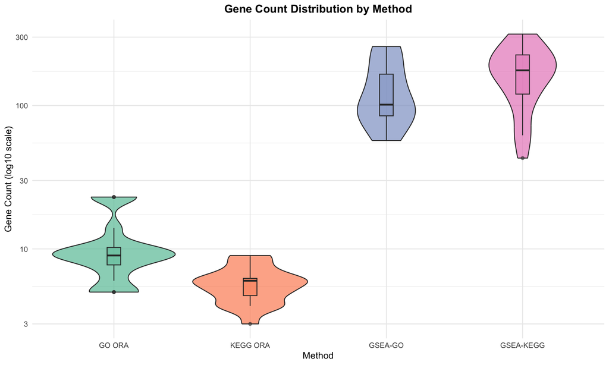

```r
p3 <- ggplot(comparison_df, aes(x = Method, y = GeneCount, fill = Method)) +
  geom_violin(alpha = 0.7) +
  geom_boxplot(width = 0.1, alpha = 0.5) +
  scale_fill_brewer(palette = "Set2") +
  scale_y_log10() +
  labs(
    title = "Gene Count Distribution by Method",
    x = "Method",
    y = "Gene Count (log10 scale)"
  ) +
  theme_minimal() +
  theme(
    legend.position = "none",
    plot.title = element_text(hjust = 0.5, face = "bold")
  )

print(p3)
```

#### 8.3.2.1 Plot Interpretation

This violin plot reveals fundamental differences in the scale of gene sets identified by each method:

**ORA Methods (GO ORA and KEGG ORA):** - **GO ORA**: Median gene count ~9-10 genes per term - Distribution is relatively narrow and centered - Most GO terms contain 5-20 genes - Represents focused, specific biological processes

- **KEGG ORA**: Median gene count ~5-6 genes per pathway
  - Lowest gene counts among all methods
  - Distribution is skewed toward smaller pathways
  - Represents highly specific pathway components

**GSEA Methods (GSEA-GO and GSEA-KEGG):** - **GSEA-GO**: Median gene count ~100 genes per term - 10-20x larger than ORA methods - Wide distribution (50-180 genes typical range) - Captures broader biological processes with many coordinated genes

#### 8.3.2.2 Key Insights

1. **Scale Difference**: GSEA methods identify pathways with 10-20x more genes than ORA methods. This reflects that GSEA captures coordinated changes across large gene sets, while ORA focuses on smaller, more specific functional units.
2. **Biological Interpretation**:
   - **ORA methods** are better for identifying specific, focused biological functions (e.g., “DNA repair” with 5-10 key genes)
   - **GSEA methods** are better for identifying broad regulatory programs (e.g., “Cell cycle” with 100+ coordinated genes)
3. **Method Selection**:
   - Use **ORA** when you want to find specific genes or small functional modules
   - Use **GSEA** when you want to detect subtle but coordinated changes across large gene networks
4. **Complementary Information**: The methods provide complementary views - ORA finds the “needles” (specific changes), while GSEA finds the “haystack” (coordinated programs).

## 8.4 Key Differences Summary

**What is this?** This section explains the main differences between the methods in simple terms, helping you understand when to use each one.

```r
cat("=== KEY DIFFERENCES ===\n\n")
```

```
## === KEY DIFFERENCES ===
```

```r
cat("1. GO ORA (Over-Representation Analysis):\n")
```

```
## 1. GO ORA (Over-Representation Analysis):
```

```r
cat("   - Uses DEGs only (padj < 0.05, |log2FC| > 1)\n")
```

```
##    - Uses DEGs only (padj < 0.05, |log2FC| > 1)
```

```r
cat("   - Tests if DEGs are over-represented in GO terms\n")
```

```
##    - Tests if DEGs are over-represented in GO terms
```

```r
cat("   - Total significant pathways:", nrow(ego@result), "\n\n")
```

```
##    - Total significant pathways: 2300
```

```r
cat("2. KEGG ORA:\n")
```

```
## 2. KEGG ORA:
```

```r
cat("   - Uses DEGs only (same as GO)\n")
```

```
##    - Uses DEGs only (same as GO)
```

```r
cat("   - Tests if DEGs are over-represented in KEGG pathways\n")
```

```
##    - Tests if DEGs are over-represented in KEGG pathways
```

```r
cat("   - Total significant pathways:", nrow(ekk@result), "\n\n")
```

```
##    - Total significant pathways: 194
```

```r
cat("3. GSEA-GO:\n")
```

```
## 3. GSEA-GO:
```

```r
cat("   - Uses ALL genes (ranked by statistic)\n")
```

```
##    - Uses ALL genes (ranked by statistic)
```

```r
cat("   - Tests if genes at extremes of ranked list are enriched\n")
```

```
##    - Tests if genes at extremes of ranked list are enriched
```

```r
cat("   - Provides NES (Normalized Enrichment Score)\n")
```

```
##    - Provides NES (Normalized Enrichment Score)
```

```r
cat("   - Total significant pathways:", nrow(gsea_go@result), "\n\n")
```

```
##    - Total significant pathways: 2919
```

```r
cat("4. GSEA-KEGG:\n")
```

```
## 4. GSEA-KEGG:
```

```r
cat("   - Uses ALL genes (ranked by statistic)\n")
```

```
##    - Uses ALL genes (ranked by statistic)
```

```r
cat("   - Tests KEGG pathways using GSEA approach\n")
```

```
##    - Tests KEGG pathways using GSEA approach
```

```r
cat("   - Provides NES (Normalized Enrichment Score)\n")
```

```
##    - Provides NES (Normalized Enrichment Score)
```

```r
cat("   - Total significant pathways:", nrow(gsea_kegg@result), "\n")
```

```
##    - Total significant pathways: 222
```

# 9 Summary

**What is this?** This final table summarizes the key characteristics of each method, helping you choose which method to use for your analysis.

| Analysis | Separate? | Input | Uses DEGs? | Provides NES? |
| --- | --- | --- | --- | --- |
| GO ORA | ✅ | DEG list | ✅ | ❌ |
| KEGG ORA | ✅ | DEG list | ✅ | ❌ |
| GSEA-GO | ✅ | Ranked genes | ❌ | ✅ |
| GSEA-KEGG | ✅ | Ranked genes | ❌ | ✅ |

**Key Point:** GO, KEGG, and GSEA are three separate enrichment analyses, each implemented independently with its own input representation and statistical framework. ORA methods (GO and KEGG) focus on DEGs, while GSEA methods use the full ranked gene list and provide enrichment scores.

# 10 Blog Visualizations

**What is this?** This section generates high-quality visualizations saved as PNG files that you can use in your blog post. All plots are saved with publication-quality settings.

## 10.1 Create Output Directory

```r
# Create directory for blog images
blog_dir <- "blog_images"
if (!dir.exists(blog_dir)) {
  dir.create(blog_dir)
}
cat("Blog images will be saved to:", blog_dir, "\n")
```

```
## Blog images will be saved to: blog_images
```

## 10.2 1. Save P-value Distribution Plot

```r
# Save p-value comparison plot
ggsave(
  filename = file.path(blog_dir, "pvalue-distribution-comparison.png"),
  plot = p1,
  width = 10,
  height = 6,
  dpi = 300,
  bg = "white"
)
cat("Saved: pvalue-distribution-comparison.png\n")
```

```
## Saved: pvalue-distribution-comparison.png
```

## 10.3 2. Save Gene Count Comparison Plot

```r
# Save gene count comparison plot
ggsave(
  filename = file.path(blog_dir, "gene-count-comparison.png"),
  plot = p3,
  width = 10,
  height = 6,
  dpi = 300,
  bg = "white"
)
cat("Saved: gene-count-comparison.png\n")
```

```
## Saved: gene-count-comparison.png
```

## 10.4 3. Save GO Enrichment Dot Plot

```r
# Save GO dot plot
if(nrow(ego@result) > 0) {
  go_dot <- dotplot(ego, showCategory = 15) +
    theme(
      plot.title = element_text(hjust = 0.5, face = "bold", size = 14),
      axis.text.y = element_text(size = 9)
    )

  ggsave(
    filename = file.path(blog_dir, "go-enrichment-dotplot.png"),
    plot = go_dot,
    width = 12,
    height = 8,
    dpi = 300,
    bg = "white"
  )
  cat("Saved: go-enrichment-dotplot.png\n")
}
```

```
## Saved: go-enrichment-dotplot.png
```

## 10.5 4. Save KEGG Enrichment Dot Plot

```r
# Save KEGG dot plot
if(nrow(ekk@result) > 0) {
  kegg_dot <- dotplot(ekk, showCategory = 15) +
    theme(
      plot.title = element_text(hjust = 0.5, face = "bold", size = 14),
      axis.text.y = element_text(size = 9)
    )

  ggsave(
    filename = file.path(blog_dir, "kegg-enrichment-dotplot.png"),
    plot = kegg_dot,
    width = 12,
    height = 8,
    dpi = 300,
    bg = "white"
  )
  cat("Saved: kegg-enrichment-dotplot.png\n")
}
```

```
## Saved: kegg-enrichment-dotplot.png
```

## 10.6 5. Save GSEA-GO Dot Plot

```r
# Save GSEA-GO dot plot
if(nrow(gsea_go@result) > 0) {
  gsea_go_dot <- dotplot(gsea_go, showCategory = 15) +
    theme(
      plot.title = element_text(hjust = 0.5, face = "bold", size = 14),
      axis.text.y = element_text(size = 9)
    )

  ggsave(
    filename = file.path(blog_dir, "gsea-go-dotplot.png"),
    plot = gsea_go_dot,
    width = 12,
    height = 8,
    dpi = 300,
    bg = "white"
  )
  cat("Saved: gsea-go-dotplot.png\n")
}
```

```
## Saved: gsea-go-dotplot.png
```

## 10.7 6. Save GSEA-KEGG Dot Plot

```r
# Save GSEA-KEGG dot plot
if(nrow(gsea_kegg@result) > 0) {
  gsea_kegg_dot <- dotplot(gsea_kegg, showCategory = 15) +
    theme(
      plot.title = element_text(hjust = 0.5, face = "bold", size = 14),
      axis.text.y = element_text(size = 9)
    )

  ggsave(
    filename = file.path(blog_dir, "gsea-kegg-dotplot.png"),
    plot = gsea_kegg_dot,
    width = 12,
    height = 8,
    dpi = 300,
    bg = "white"
  )
  cat("Saved: gsea-kegg-dotplot.png\n")
}
```

```
## Saved: gsea-kegg-dotplot.png
```

## 10.8 7. Save Top GSEA Enrichment Plot (GO)

```r
# Save top GSEA-GO enrichment plot
if(nrow(gsea_go@result) > 0) {
  # Get top enriched pathway
  top_pathway_id <- gsea_go@result$ID[1]
  top_pathway_desc <- gsea_go@result$Description[1]

  gsea_plot_go <- gseaplot2(
    gsea_go,
    geneSetID = top_pathway_id,
    title = top_pathway_desc,
    pvalue_table = TRUE
  )

  # Save as PNG
  png(
    filename = file.path(blog_dir, "gsea-go-top-pathway.png"),
    width = 12,
    height = 8,
    units = "in",
    res = 300,
    bg = "white"
  )
  print(gsea_plot_go)
  dev.off()
  cat("Saved: gsea-go-top-pathway.png\n")
}
```

```
## Saved: gsea-go-top-pathway.png
```

## 10.9 8. Save Top GSEA Enrichment Plot (KEGG)

```r
# Save top GSEA-KEGG enrichment plot
if(nrow(gsea_kegg@result) > 0) {
  # Get top enriched pathway
  top_pathway_id <- gsea_kegg@result$ID[1]
  top_pathway_desc <- gsea_kegg@result$Description[1]

  gsea_plot_kegg <- gseaplot2(
    gsea_kegg,
    geneSetID = top_pathway_id,
    title = top_pathway_desc,
    pvalue_table = TRUE
  )

  # Save as PNG
  png(
    filename = file.path(blog_dir, "gsea-kegg-top-pathway.png"),
    width = 12,
    height = 8,
    units = "in",
    res = 300,
    bg = "white"
  )
  print(gsea_plot_kegg)
  dev.off()
  cat("Saved: gsea-kegg-top-pathway.png\n")
}
```

```
## Saved: gsea-kegg-top-pathway.png
```

## 10.10 9. Create Combined Comparison Plot

```r
# Create a combined comparison plot
if(exists("p1") && exists("p3")) {
  # Combine p-value and gene count plots
  combined_plot <- p1 / p3 +
    plot_annotation(
      title = "Comprehensive Comparison: GO vs KEGG vs GSEA",
      theme = theme(
        plot.title = element_text(hjust = 0.5, face = "bold", size = 16),
        plot.margin = margin(20, 20, 20, 20)
      )
    )

  ggsave(
    filename = file.path(blog_dir, "combined-comparison-plot.png"),
    plot = combined_plot,
    width = 12,
    height = 12,
    dpi = 300,
    bg = "white"
  )
  cat("Saved: combined-comparison-plot.png\n")
}
```

```
## Saved: combined-comparison-plot.png
```

## 10.11 10. Create Method Comparison Summary Plot

```r
# Create a summary visualization showing key differences
if(exists("comparison_df")) {
  # Create a summary plot
  summary_data <- comparison_df %>%
    group_by(Method) %>%
    summarise(
      n_pathways = n(),
      mean_gene_count = mean(GeneCount, na.rm = TRUE),
      mean_log10padj = mean(log10Padj, na.rm = TRUE),
      .groups = "drop"
    )

  # Create a bar plot for pathway counts
  p_pathways <- ggplot(summary_data, aes(x = Method, y = n_pathways, fill = Method)) +
    geom_bar(stat = "identity", alpha = 0.8) +
    scale_fill_brewer(palette = "Set2") +
    labs(
      title = "Number of Enriched Pathways by Method",
      x = "Method",
      y = "Number of Pathways"
    ) +
    theme_minimal() +
    theme(
      legend.position = "none",
      plot.title = element_text(hjust = 0.5, face = "bold")
    )

  # Create a bar plot for mean gene count
  p_mean_genes <- ggplot(summary_data, aes(x = Method, y = mean_gene_count, fill = Method)) +
    geom_bar(stat = "identity", alpha = 0.8) +
    scale_fill_brewer(palette = "Set2") +
    scale_y_log10() +
    labs(
      title = "Mean Gene Count per Pathway",
      x = "Method",
      y = "Mean Gene Count (log10 scale)"
    ) +
    theme_minimal() +
    theme(
      legend.position = "none",
      plot.title = element_text(hjust = 0.5, face = "bold")
    )

  # Combine plots
  summary_combined <- p_pathways | p_mean_genes

  ggsave(
    filename = file.path(blog_dir, "method-summary-comparison.png"),
    plot = summary_combined,
    width = 14,
    height = 6,
    dpi = 300,
    bg = "white"
  )
  cat("Saved: method-summary-comparison.png\n")
}
```

```
## Saved: method-summary-comparison.png
```

## 10.12 11. Create NES Distribution Plot (GSEA only)

```r
# Create NES distribution plot for GSEA methods
if(exists("comparison_df")) {
  gsea_only <- comparison_df %>%
    filter(Method %in% c("GSEA-GO", "GSEA-KEGG")) %>%
    filter(!is.na(EnrichmentScore))

  if(nrow(gsea_only) > 0) {
    p_nes <- ggplot(gsea_only, aes(x = Method, y = EnrichmentScore, fill = Method)) +
      geom_boxplot(alpha = 0.7) +
      geom_jitter(width = 0.2, alpha = 0.3, size = 0.5) +
      geom_hline(yintercept = 0, linetype = "dashed", color = "red", linewidth = 0.8) +
      scale_fill_brewer(palette = "Set2") +
      labs(
        title = "Normalized Enrichment Score (NES) Distribution",
        subtitle = "GSEA Methods Only - Positive = Activation, Negative = Suppression",
        x = "Method",
        y = "Normalized Enrichment Score (NES)"
      ) +
      theme_minimal() +
      theme(
        legend.position = "none",
        plot.title = element_text(hjust = 0.5, face = "bold"),
        plot.subtitle = element_text(hjust = 0.5)
      )

    ggsave(
      filename = file.path(blog_dir, "nes-distribution-gsea.png"),
      plot = p_nes,
      width = 10,
      height = 6,
      dpi = 300,
      bg = "white"
    )
    cat("Saved: nes-distribution-gsea.png\n")
  }
}
```

```
## Saved: nes-distribution-gsea.png
```

## 10.13 12. Create Top Pathways Bar Chart

```r
# Create bar chart of top pathways from each method
if(exists("comparison_df")) {
  # Get top 5 pathways from each method
  top_pathways <- comparison_df %>%
    group_by(Method) %>%
    top_n(5, wt = -Padj) %>%
    ungroup() %>%
    mutate(
      Pathway_short = ifelse(nchar(Pathway) > 50,
                            paste0(substr(Pathway, 1, 47), "..."),
                            Pathway)
    )

  p_top <- ggplot(top_pathways,
                  aes(x = reorder(Pathway_short, -log10Padj),
                      y = log10Padj,
                      fill = Method)) +
    geom_bar(stat = "identity", alpha = 0.8) +
    coord_flip() +
    facet_wrap(~ Method, scales = "free_y", ncol = 2) +
    scale_fill_brewer(palette = "Set2") +
    labs(
      title = "Top 5 Pathways by Method",
      x = "Pathway",
      y = "-log10(Adjusted P-value)"
    ) +
    theme_minimal() +
    theme(
      legend.position = "none",
      plot.title = element_text(hjust = 0.5, face = "bold"),
      axis.text.y = element_text(size = 8),
      strip.text = element_text(face = "bold")
    )

  ggsave(
    filename = file.path(blog_dir, "top-pathways-by-method.png"),
    plot = p_top,
    width = 14,
    height = 10,
    dpi = 300,
    bg = "white"
  )
  cat("Saved: top-pathways-by-method.png\n")
}
```

```
## Saved: top-pathways-by-method.png
```

## 10.14 Summary of Saved Images

```
##
## === Saved Blog Images ===
## Total images saved: 12
##
## - combined-comparison-plot.png
## - gene-count-comparison.png
## - go-enrichment-dotplot.png
## - gsea-go-dotplot.png
## - gsea-go-top-pathway.png
## - gsea-kegg-dotplot.png
## - gsea-kegg-top-pathway.png
## - kegg-enrichment-dotplot.png
## - method-summary-comparison.png
## - nes-distribution-gsea.png
## - pvalue-distribution-comparison.png
## - top-pathways-by-method.png
##
## All images saved to: blog_images
## You can now use these images in your blog post!
```